# BusinessData

## Linear Regression

We need to predict the employment number by using the data which we have for various polulation, army , inflation.

We need to build a model such that if we have the data of above values then we can predict the employment. The data was random collection and the county and other confidential fields are not provided for analysis.

Data is of GNP.deflator, GNP Unemployed, Armed.Forces, Population, Employed variables. We have to use the data for prediction of the Employed variable.

## Importing LIbraries

```python
import pandas as pd
import numpy as np
import seaborn as sns
import matplotlib
%matplotlib inline
from matplotlib import pyplot as plt
```

## Understanding Data

```python
BusinessData = pd.read_csv("LR Practice data.csv")
```

```python
BusinessData.shape
```

```
(2938, 6)
```

```python
BusinessData.head()
```

|  | GNP.deflator | GNP | Unemployed | Armed.Forces | Population | Employed |
| --- | --- | --- | --- | --- | --- | --- |
| 0 | 83.0 | 234.289 | 235.6 | 159.0 | 107.608 | 60.323 |
| 1 | 88.5 | 259.426 | 232.5 | 145.6 | 108.632 | 61.122 |
| 2 | 88.2 | 258.054 | 368.2 | 161.6 | 109.773 | 60.171 |
| 3 | 89.5 | 284.599 | 335.1 | 165.0 | 110.929 | 61.187 |
| 4 | 96.2 | 328.975 | 209.9 | 309.9 | 112.075 | 63.221 |

## Lets check the data type

```python
BusinessData.dtypes

# types of dataset
```

```
GNP.deflator    float64
GNP             float64
Unemployed      float64
Armed.Forces    float64
Population      float64
Employed        float64
dtype: object
```

```python
BusinessData.count()

# total number
```

```
GNP.deflator    2938
GNP             2938
Unemployed      2938
Armed.Forces    2938
Population      2938
Employed        2938
dtype: int64
```

## Let's check the summary of data

```python
BusinessData.info()

# summary of dataset
```

```
<class 'pandas.core.frame.DataFrame'>
RangeIndex: 2938 entries, 0 to 2937
Data columns (total 6 columns):
 #   Column        Non-Null Count  Dtype
---  ------        --------------  -----
 0   GNP.deflator  2938 non-null   float64
 1   GNP           2938 non-null   float64
 2   Unemployed    2938 non-null   float64
 3   Armed.Forces  2938 non-null   float64
 4   Population    2938 non-null   float64
 5   Employed      2938 non-null   float64
dtypes: float64(6)
memory usage: 137.8 KB
```

```python
BusinessData.describe()
```

|  | GNP.deflator | GNP | Unemployed | Armed.Forces | Population | Employed |
| --- | --- | --- | --- | --- | --- | --- |
| count | 2938.000000 | 2938.000000 | 2938.000000 | 2938.000000 | 2938.000000 | 2938.000000 |
| mean | 3383.989632 | 30744.994551 | 19482.279926 | 9171.264779 | 2239.144062 | 1112.140688 |
| std | 1905.742557 | 17625.763439 | 11126.209407 | 5173.587165 | 1231.892846 | 607.796778 |
| min | 83.000000 | 234.289000 | 187.000000 | 145.600000 | 107.608000 | 60.171000 |
| 25% | 1734.410625 | 15488.427358 | 9851.619375 | 4693.095625 | 1172.838137 | 586.041925 |
| 50% | 3383.989632 | 30744.994550 | 19482.279925 | 9171.264780 | 2239.144062 | 1112.140688 |
| 75% | 5033.568639 | 46001.561743 | 29112.940480 | 13649.433937 | 3305.449986 | 1638.239451 |
| max | 6683.147647 | 61258.128940 | 38743.601030 | 18127.603090 | 4371.755910 | 2164.338215 |

## Total Unique Value

```python
BusinessData.nunique()

# unique values
```

```
GNP.deflator    2938
GNP             2938
Unemployed      2938
Armed.Forces    2938
Population      2938
Employed        2938
dtype: int64
```

## Missing Value

```python
BusinessData.isnull().sum()

# missing value
```

```
GNP.deflator    0
GNP             0
Unemployed      0
Armed.Forces    0
Population      0
Employed        0
dtype: int64
```

As we saw there is no missing value here.

## Visualising Data

### **Relationship**

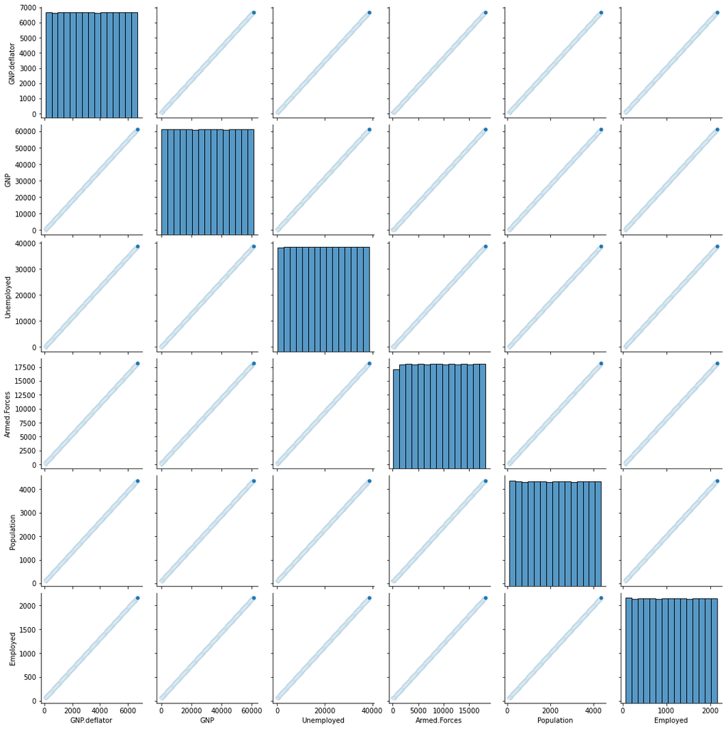

```python
sns.pairplot(BusinessData)
```

## Correlation matrix

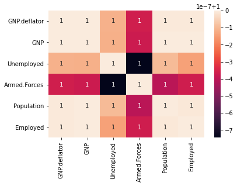

```python
sns.heatmap(BusinessData.corr() , annot = True)
```

### All the columns are Numerical columns

# Regression

```python
# Independent Variable = feature variable = Predictor variable

x = BusinessData.drop(columns=['Employed'])

# Dependent Variable = Response variable

y = BusinessData[['Employed']]
```

# Spliting the data into Train & Test

```python
from sklearn.model_selection import train_test_split

x_train , x_test , y_train , y_test = train_test_split(x, y, train_size = 0.7, random_state = 0)
```

# Performing Regression

```python
from sklearn.linear_model import LinearRegression

# created an instance of "LinearRegression" class

model = LinearRegression()
```

```python
model.fit(x_train , y_train)

# fitting the model to train data
```

```
LinearRegression(copy_X=True, fit_intercept=True, n_jobs=None, normalize=False)
```

```python
x_train
```

|  | GNP.deflator | GNP | Unemployed | Armed.Forces | Population |
| --- | --- | --- | --- | --- | --- |
| 1662 | 3818.710147 | 34765.622060 | 22020.288530 | 10351.415590 | 2520.152160 |
| 2219 | 5070.076176 | 46339.211340 | 29326.080740 | 13748.542210 | 3329.048857 |
| 17 | 123.024118 | 585.093587 | 443.936324 | 318.608971 | 131.220263 |
| 58 | 215.135441 | 1437.009494 | 981.705588 | 568.666765 | 190.762031 |
| 568 | 1360.910441 | 12034.012240 | 7671.030588 | 3679.141765 | 931.403531 |
| ... | ... | ... | ... | ... | ... |
| 763 | 1799.000882 | 16085.807410 | 10228.713680 | 4868.441029 | 1214.589987 |
| 835 | 1960.757353 | 17581.854860 | 11173.088970 | 5307.566912 | 1319.151140 |
| 1653 | 3798.490588 | 34578.616130 | 21902.241620 | 10296.524850 | 2507.082016 |
| 2607 | 5941.763824 | 54401.244810 | 34415.214260 | 16114.942790 | 3892.517293 |
| 2732 | 6222.591029 | 56998.549400 | 36054.754710 | 16877.314120 | 4074.047072 |

2056 rows × 5 columns

# Model Evaluation

```python
model.intercept_

# Intercept = c
```

```
array([57.17681203])
```

```python
model.coef_

# Coeficient = m1 , m2 , m3 , _ _ _ _ _ _ _ _ _
```

```
array([[-0.07071764,  0.04719288, -0.00619283, -0.00408509,  0.00064409]])
```

# Predictions

```python
y_pred = model.predict(x_test)
```

```python
y_pred.shape
```

```
(882, 1)
```

```python
y_test
```

|  | Employed |
| --- | --- |
| 867 | 681.158862 |
| 1780 | 1335.334103 |
| 621 | 504.896968 |
| 2715 | 2005.272603 |
| 2717 | 2006.705626 |
| ... | ... |
| 1212 | 928.355421 |
| 1160 | 891.096809 |
| 391 | 340.099262 |
| 1515 | 1145.458485 |
| 220 | 217.575750 |

882 rows × 1 columns

```python
y_pred - y_test

# error = y_test - y_pred
```

|  | Employed |
| --- | --- |
| 867 | -0.000572 |
| 1780 | -0.000093 |
| 621 | -0.000701 |
| 2715 | 0.000399 |
| 2717 | 0.000400 |
| ... | ... |
| 1212 | -0.000391 |
| 1160 | -0.000418 |
| 391 | -0.000822 |
| 1515 | -0.000231 |
| 220 | -0.000912 |

882 rows × 1 columns

```python
import warnings
warnings.filterwarnings("ignore")
```

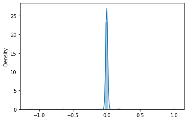

```python
sns.distplot(y_pred - y_test)

# Distribution plot of (y_pred - y_test)
```

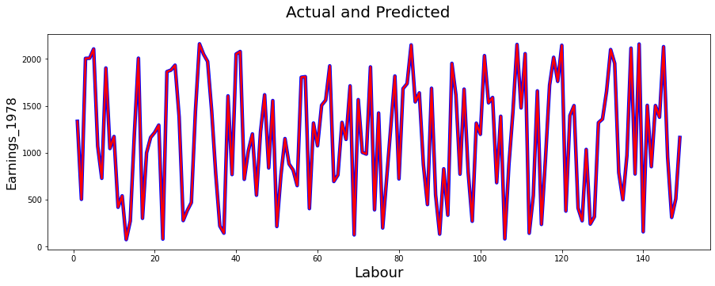

```python
#Actual vs Predicted
# Check for the forst 150 observations

c = [i for i in range(1,150,1)]
fig = plt.figure(figsize=(15,5))
plt.plot(c,y_test[1:150], color="blue", linewidth=4.5, linestyle="-")
plt.plot(c,y_pred[1:150], color="red",  linewidth=2.5, linestyle="-")
fig.suptitle('Actual and Predicted', fontsize=20)
plt.xlabel('Labour', fontsize=18)
plt.ylabel('Earnings_1978', fontsize=16)
```

# Model Performance Metrics

```python
from sklearn import metrics
```

```python
R_square = metrics.r2_score(y_test,y_pred)

print('R square :',R_square)

# Value of R_square = 1 - (square of sum os error/total sum of squares)
```

```
R square : 0.9999999916370588
```

```python
Mean_square_error = metrics.mean_squared_error(y_test,y_pred)

print("Mean square error :" ,Mean_square_error)

# error = y_test - y_pred
# square_error = (y_test - y_pred)^2
# mean_square_error = mean of (y_test - y_pred)^2

# we take error for every value & also take the (error)^2 , then add all then we took mean
```

```
Mean square error : 0.0031328931014294676
```

```python
Root_Mean_squared_error = np.sqrt(Mean_square_error)

print("Root mean square error :" ,Root_Mean_squared_error)

# square root of mean_square_error
```

```
Root mean square error : 0.055972252960100395
```

The value of R Square is 99.99% of the variation in Y can be explained with the help of given explanatory variables in that model.

- Error is very low
- Accuracy is very high
- R Square = 99.99%

# Adjusted R square

```python
# n = sample size

n = x_test.shape[0]
n
```

```
882
```

```python
# k = no of independent variables

k = x_test.shape[1]
k
```

```
5
```

```python
Adj_R2 = 1 - ((n-1)/(n-k-1))*(1- R_square)

print("Adjusted R square :" ,Adj_R2)
```

```
Adjusted R square : 0.9999999915893251
```

- Adjusted R Square = 99.99%

# Stats Model

```python
import statsmodels.api as sm
```

```python
x_train_sm = sm.add_constant(x_train)
```

```python
stats_model = sm.OLS(y_train,x_train_sm).fit()
```

```python
stats_model.summary()
```

OLS Regression Results

| Dep. Variable: | Employed | R-squared: | 1.000 |
| --- | --- | --- | --- |
| Model: | OLS | Adj. R-squared: | 1.000 |
| Method: | Least Squares | F-statistic: | 7.742e+11 |
| Date: | Wed, 06 Jan 2021 | Prob (F-statistic): | 0.00 |
| Time: | 21:21:18 | Log-Likelihood: | 5867.7 |
| No. Observations: | 2056 | AIC: | -1.172e+04 |
| Df Residuals: | 2050 | BIC: | -1.169e+04 |
| Df Model: | 5 |  |  |
| Covariance Type: | nonrobust |  |  |

|  | coef | std err | t | P>\|t\| | [0.025 | 0.975] |
| --- | --- | --- | --- | --- | --- | --- |
| const | 57.1768 | 1.305 | 43.805 | 0.000 | 54.617 | 59.737 |
| GNP.deflator | -0.0707 | 0.004 | -16.901 | 0.000 | -0.079 | -0.063 |
| GNP | 0.0472 | 0.001 | 42.408 | 0.000 | 0.045 | 0.049 |
| Unemployed | -0.0062 | 0.000 | -39.620 | 0.000 | -0.006 | -0.006 |
| Armed.Forces | -0.0041 | 8.87e-05 | -46.034 | 0.000 | -0.004 | -0.004 |
| Population | 0.0006 | 0.013 | 0.050 | 0.960 | -0.025 | 0.026 |

| Omnibus: | 4690.373 | Durbin-Watson: | 2.000 |
| --- | --- | --- | --- |
| Prob(Omnibus): | 0.000 | Jarque-Bera (JB): | 40434105.764 |
| Skew: | -20.970 | Prob(JB): | 0.00 |
| Kurtosis: | 688.736 | Cond. No. | 1.84e+08 |

Warnings:  
[1] Standard Errors assume that the covariance matrix of the errors is correctly specified.  
[2] The condition number is large, 1.84e+08. This might indicate that there are  
strong multicollinearity or other numerical problems.

### As R Square is 99.99% & Adjusted R Square is 99.99%

### This mean the model is prefectly fit

## Multicollinearity

- If independent valriables Xi’s are highly correlated then |X’X| will be close to 0 and hence inverse of (X’X) will not exist or will be indefinitely large. Mathematically, which will be indefinitely large in presence of multicollinearity. Long story in short, multicollinearity increases the estimate of standard error of regression coefficients which makes some variables statistically insignificant when they should be significant.

## Implementing the results

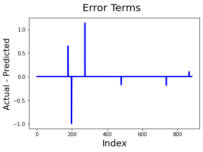

```python
# Error terms
c = [i for i in range(1,883,1)]
fig = plt.figure()
plt.plot(c,y_test-y_pred, color="blue", linewidth=2.5, linestyle="-")
fig.suptitle('Error Terms', fontsize=20)              # Plot heading
plt.xlabel('Index', fontsize=18)                      # X-label
plt.ylabel('Actual - Predicted', fontsize=16)                # Y-label
```

## VIF (Variance Inflation Factor) Method:

- Firstly we fit a model with all the variables and then calculate the variance inflation factor (VIF) for each variable. VIF measures how much the variance of an estimated regression coefficient increases if your predictors are correlated. The higher the value of VIF for ith regressor, the more it is highly correlated to other variables

## Variance Inflation Factor

## Variance inflation factor (VIF) for an explanatory variable is given 1/(1-R^2 ) .

#### Here, we take that particular X as response variable and all other explanatory variables as independent variables. So, we run a regression between one of those explanatory variables with remaining explanatory variables.

```python
from statsmodels.stats.outliers_influence import variance_inflation_factor
```

```python
# For each X, calculate VIF and save in dataframe

vif = pd.DataFrame()
vif["VIF Factor"] = [variance_inflation_factor(x.values, i) for i in range(x.shape[1])]
vif["features"] = x.columns
```

```python
vif.round(2)
```

|  | VIF Factor | features |
| --- | --- | --- |
| 0 | 1.380650e+09 | GNP.deflator |
| 1 | 4.048266e+08 | GNP |
| 2 | 3.131883e+07 | Unemployed |
| 3 | 1.122200e+07 | Armed.Forces |
| 4 | 2.426823e+08 | Population |